< return home

# Housing Price Prediction with Regression & Ensembling

This project came from the ongoing Kaggle competition [House Prices: Advanced Regression Techniques](https://www.kaggle.com/c/house-prices-advanced-regression-techniques/overview).

```python
import numpy as np
import pandas as pd
import matplotlib.pyplot as plt
import seaborn as sns
from scipy import stats
import missingno as msno

import warnings
warnings.filterwarnings('ignore')
```

```python
train_df = pd.read_csv('train.csv')
test_df = pd.read_csv('test.csv')
```

## Initial EDA

```python
train_df
```

|  | Id | MSSubClass | MSZoning | LotFrontage | LotArea | Street | Alley | LotShape | LandContour | Utilities | ... | PoolArea | PoolQC | Fence | MiscFeature | MiscVal | MoSold | YrSold | SaleType | SaleCondition | SalePrice |
| --- | --- | --- | --- | --- | --- | --- | --- | --- | --- | --- | --- | --- | --- | --- | --- | --- | --- | --- | --- | --- | --- |
| 0 | 1 | 60 | RL | 65.0 | 8450 | Pave | NaN | Reg | Lvl | AllPub | ... | 0 | NaN | NaN | NaN | 0 | 2 | 2008 | WD | Normal | 208500 |
| 1 | 2 | 20 | RL | 80.0 | 9600 | Pave | NaN | Reg | Lvl | AllPub | ... | 0 | NaN | NaN | NaN | 0 | 5 | 2007 | WD | Normal | 181500 |
| 2 | 3 | 60 | RL | 68.0 | 11250 | Pave | NaN | IR1 | Lvl | AllPub | ... | 0 | NaN | NaN | NaN | 0 | 9 | 2008 | WD | Normal | 223500 |
| 3 | 4 | 70 | RL | 60.0 | 9550 | Pave | NaN | IR1 | Lvl | AllPub | ... | 0 | NaN | NaN | NaN | 0 | 2 | 2006 | WD | Abnorml | 140000 |
| 4 | 5 | 60 | RL | 84.0 | 14260 | Pave | NaN | IR1 | Lvl | AllPub | ... | 0 | NaN | NaN | NaN | 0 | 12 | 2008 | WD | Normal | 250000 |
| ... | ... | ... | ... | ... | ... | ... | ... | ... | ... | ... | ... | ... | ... | ... | ... | ... | ... | ... | ... | ... | ... |
| 1455 | 1456 | 60 | RL | 62.0 | 7917 | Pave | NaN | Reg | Lvl | AllPub | ... | 0 | NaN | NaN | NaN | 0 | 8 | 2007 | WD | Normal | 175000 |
| 1456 | 1457 | 20 | RL | 85.0 | 13175 | Pave | NaN | Reg | Lvl | AllPub | ... | 0 | NaN | MnPrv | NaN | 0 | 2 | 2010 | WD | Normal | 210000 |
| 1457 | 1458 | 70 | RL | 66.0 | 9042 | Pave | NaN | Reg | Lvl | AllPub | ... | 0 | NaN | GdPrv | Shed | 2500 | 5 | 2010 | WD | Normal | 266500 |
| 1458 | 1459 | 20 | RL | 68.0 | 9717 | Pave | NaN | Reg | Lvl | AllPub | ... | 0 | NaN | NaN | NaN | 0 | 4 | 2010 | WD | Normal | 142125 |
| 1459 | 1460 | 20 | RL | 75.0 | 9937 | Pave | NaN | Reg | Lvl | AllPub | ... | 0 | NaN | NaN | NaN | 0 | 6 | 2008 | WD | Normal | 147500 |

1460 rows × 81 columns

```python
test_df
```

|  | Id | MSSubClass | MSZoning | LotFrontage | LotArea | Street | Alley | LotShape | LandContour | Utilities | ... | ScreenPorch | PoolArea | PoolQC | Fence | MiscFeature | MiscVal | MoSold | YrSold | SaleType | SaleCondition |
| --- | --- | --- | --- | --- | --- | --- | --- | --- | --- | --- | --- | --- | --- | --- | --- | --- | --- | --- | --- | --- | --- |
| 0 | 1461 | 20 | RH | 80.0 | 11622 | Pave | NaN | Reg | Lvl | AllPub | ... | 120 | 0 | NaN | MnPrv | NaN | 0 | 6 | 2010 | WD | Normal |
| 1 | 1462 | 20 | RL | 81.0 | 14267 | Pave | NaN | IR1 | Lvl | AllPub | ... | 0 | 0 | NaN | NaN | Gar2 | 12500 | 6 | 2010 | WD | Normal |
| 2 | 1463 | 60 | RL | 74.0 | 13830 | Pave | NaN | IR1 | Lvl | AllPub | ... | 0 | 0 | NaN | MnPrv | NaN | 0 | 3 | 2010 | WD | Normal |
| 3 | 1464 | 60 | RL | 78.0 | 9978 | Pave | NaN | IR1 | Lvl | AllPub | ... | 0 | 0 | NaN | NaN | NaN | 0 | 6 | 2010 | WD | Normal |
| 4 | 1465 | 120 | RL | 43.0 | 5005 | Pave | NaN | IR1 | HLS | AllPub | ... | 144 | 0 | NaN | NaN | NaN | 0 | 1 | 2010 | WD | Normal |
| ... | ... | ... | ... | ... | ... | ... | ... | ... | ... | ... | ... | ... | ... | ... | ... | ... | ... | ... | ... | ... | ... |
| 1454 | 2915 | 160 | RM | 21.0 | 1936 | Pave | NaN | Reg | Lvl | AllPub | ... | 0 | 0 | NaN | NaN | NaN | 0 | 6 | 2006 | WD | Normal |
| 1455 | 2916 | 160 | RM | 21.0 | 1894 | Pave | NaN | Reg | Lvl | AllPub | ... | 0 | 0 | NaN | NaN | NaN | 0 | 4 | 2006 | WD | Abnorml |
| 1456 | 2917 | 20 | RL | 160.0 | 20000 | Pave | NaN | Reg | Lvl | AllPub | ... | 0 | 0 | NaN | NaN | NaN | 0 | 9 | 2006 | WD | Abnorml |
| 1457 | 2918 | 85 | RL | 62.0 | 10441 | Pave | NaN | Reg | Lvl | AllPub | ... | 0 | 0 | NaN | MnPrv | Shed | 700 | 7 | 2006 | WD | Normal |
| 1458 | 2919 | 60 | RL | 74.0 | 9627 | Pave | NaN | Reg | Lvl | AllPub | ... | 0 | 0 | NaN | NaN | NaN | 0 | 11 | 2006 | WD | Normal |

1459 rows × 80 columns

```python
train_df.describe()
```

|  | Id | MSSubClass | LotFrontage | LotArea | OverallQual | OverallCond | YearBuilt | YearRemodAdd | MasVnrArea | BsmtFinSF1 | ... | WoodDeckSF | OpenPorchSF | EnclosedPorch | 3SsnPorch | ScreenPorch | PoolArea | MiscVal | MoSold | YrSold | SalePrice |
| --- | --- | --- | --- | --- | --- | --- | --- | --- | --- | --- | --- | --- | --- | --- | --- | --- | --- | --- | --- | --- | --- |
| count | 1460.000000 | 1460.000000 | 1201.000000 | 1460.000000 | 1460.000000 | 1460.000000 | 1460.000000 | 1460.000000 | 1452.000000 | 1460.000000 | ... | 1460.000000 | 1460.000000 | 1460.000000 | 1460.000000 | 1460.000000 | 1460.000000 | 1460.000000 | 1460.000000 | 1460.000000 | 1460.000000 |
| mean | 730.500000 | 56.897260 | 70.049958 | 10516.828082 | 6.099315 | 5.575342 | 1971.267808 | 1984.865753 | 103.685262 | 443.639726 | ... | 94.244521 | 46.660274 | 21.954110 | 3.409589 | 15.060959 | 2.758904 | 43.489041 | 6.321918 | 2007.815753 | 180921.195890 |
| std | 421.610009 | 42.300571 | 24.284752 | 9981.264932 | 1.382997 | 1.112799 | 30.202904 | 20.645407 | 181.066207 | 456.098091 | ... | 125.338794 | 66.256028 | 61.119149 | 29.317331 | 55.757415 | 40.177307 | 496.123024 | 2.703626 | 1.328095 | 79442.502883 |
| min | 1.000000 | 20.000000 | 21.000000 | 1300.000000 | 1.000000 | 1.000000 | 1872.000000 | 1950.000000 | 0.000000 | 0.000000 | ... | 0.000000 | 0.000000 | 0.000000 | 0.000000 | 0.000000 | 0.000000 | 0.000000 | 1.000000 | 2006.000000 | 34900.000000 |
| 25% | 365.750000 | 20.000000 | 59.000000 | 7553.500000 | 5.000000 | 5.000000 | 1954.000000 | 1967.000000 | 0.000000 | 0.000000 | ... | 0.000000 | 0.000000 | 0.000000 | 0.000000 | 0.000000 | 0.000000 | 0.000000 | 5.000000 | 2007.000000 | 129975.000000 |
| 50% | 730.500000 | 50.000000 | 69.000000 | 9478.500000 | 6.000000 | 5.000000 | 1973.000000 | 1994.000000 | 0.000000 | 383.500000 | ... | 0.000000 | 25.000000 | 0.000000 | 0.000000 | 0.000000 | 0.000000 | 0.000000 | 6.000000 | 2008.000000 | 163000.000000 |
| 75% | 1095.250000 | 70.000000 | 80.000000 | 11601.500000 | 7.000000 | 6.000000 | 2000.000000 | 2004.000000 | 166.000000 | 712.250000 | ... | 168.000000 | 68.000000 | 0.000000 | 0.000000 | 0.000000 | 0.000000 | 0.000000 | 8.000000 | 2009.000000 | 214000.000000 |
| max | 1460.000000 | 190.000000 | 313.000000 | 215245.000000 | 10.000000 | 9.000000 | 2010.000000 | 2010.000000 | 1600.000000 | 5644.000000 | ... | 857.000000 | 547.000000 | 552.000000 | 508.000000 | 480.000000 | 738.000000 | 15500.000000 | 12.000000 | 2010.000000 | 755000.000000 |

8 rows × 38 columns

### Correlation of Numerical Variables

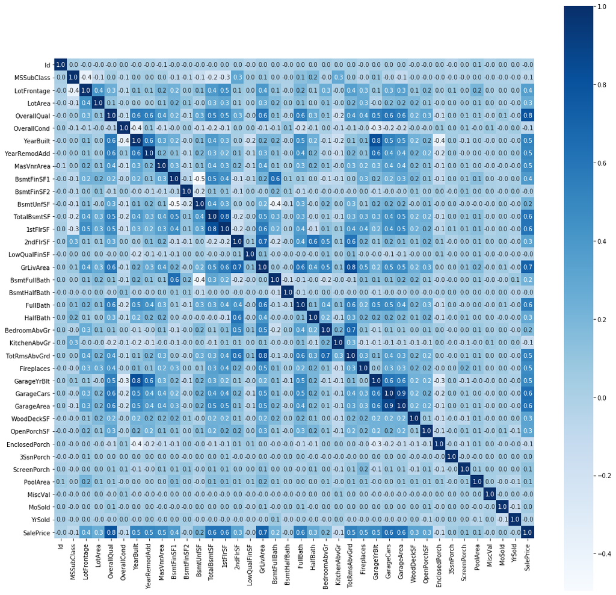

```python
plt.figure(figsize=(18,18))
sns.heatmap(train_df.corr(),annot=True,cmap="Blues",fmt='.1f',square=True)
```

Interesting... We can see that OverallQual and many of the area/sqft-related variables are highly correlated with our SalePrice target variable. Furthermore, notice that many independent variables are correlated with each other... it's important to keep in mind that linear regression models (like the ones we'll be using for predictive purposes later on in this notebook) require independent variables to have little to no collinearity. We'll keep these variables for now, however, as we can account for collinearity through regularization (i.e. Lasso, Ridge) later on.

## Data Preprocessing

### Removing Unnecessary Columns

First, let's drop the ID column. There may be others, but for now ID is an obvious choice.

```python
train_df.drop(['Id'],axis=1,inplace=True)
test_df.drop(['Id'],axis=1,inplace=True)
```

### Outliers

Now let's look for potential outliers and address them.

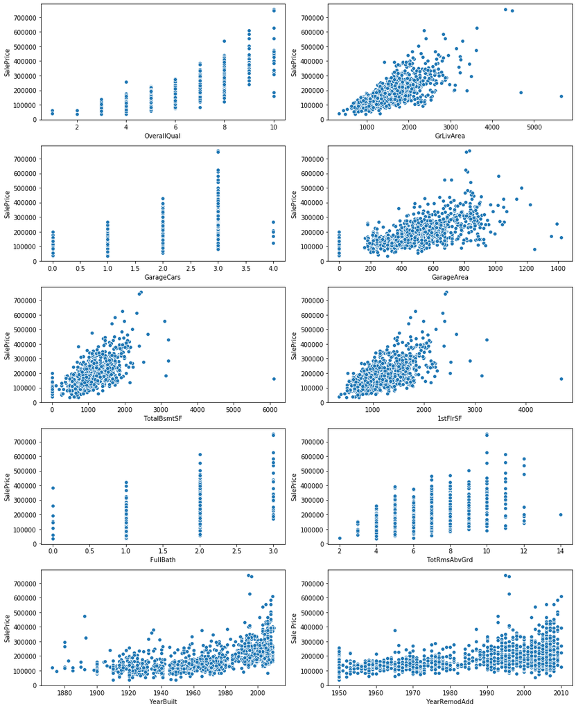

```python
# View features that are highly correlated with SalePrice
corrs = train_df.corr()[['SalePrice']]
corrs = corrs[corrs['SalePrice']>0.5]
corrs = corrs.sort_values(by='SalePrice',ascending=False)

high_corr_feats = corrs.index[1:]

fig, axes = plt.subplots(5,2,figsize=(13,16))

for i, ax in enumerate(axes.flatten()):
    feat = high_corr_feats[i]
    sns.scatterplot(x=train_df[feat], y=train_df['SalePrice'], ax=ax)
    plt.xlabel(feat)
    plt.ylabel('Sale Price')
plt.tight_layout()
```

On GrLivArea, it looks like those two points on the bottom right are outliers, given they have such high GrLivArea and low SalePrice. Same for the points on the bottom right of TotalBsmtSF and 1stFlrSF. Let's drop these for now.

```python
train_df.shape
```

```
(1460, 80)
```

```python
# Drop GrLivArea outliers
train_df.drop(train_df[(train_df['SalePrice'] < 300000) &
                       (train_df['GrLivArea'] > 4000)].index,
                       inplace=True)

# Drop TotalBsmtSF and 1stFlrSF outliers
train_df.drop(train_df[(train_df['TotalBsmtSF'] > 6000) |
                       (train_df['1stFlrSF'] > 4000)].index,
                       inplace=True)
```

```python
train_df.shape
```

```
(1458, 80)
```

Great! Looks like these outliers boiled down to just two points. Let's visualize the graphs again to ensure all outliers were removed.

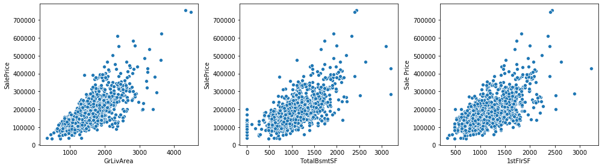

```python
fig, axes = plt.subplots(1,3,figsize=(14,4))
feats = ['GrLivArea', 'TotalBsmtSF', '1stFlrSF']

for i, ax in enumerate(axes.flatten()):
    feat = feats[i]
    sns.scatterplot(x=train_df[feat], y=train_df['SalePrice'], ax=ax)
    plt.xlabel(feat)
    plt.ylabel('Sale Price')

plt.tight_layout()
```

Success! There are likely other outliers, but we will address these later on in our analysis in a more automated way using outlier_test() from statsmodels.api.

### Null Values

Now, let's get an idea of the null values in our data, and let's figure out how best to replace them. First, we'll concatenate the train and test data into one df.

```python
df = pd.concat([train_df.drop(['SalePrice'],axis=1),
                test_df]).reset_index(drop=True)
df.shape
```

```
(2917, 79)
```

Awesome, now let's visualize our null values in a few different ways: msno matrices, a bargraph showing feature null-value percentages, and a table showing null-value totals & percentages.

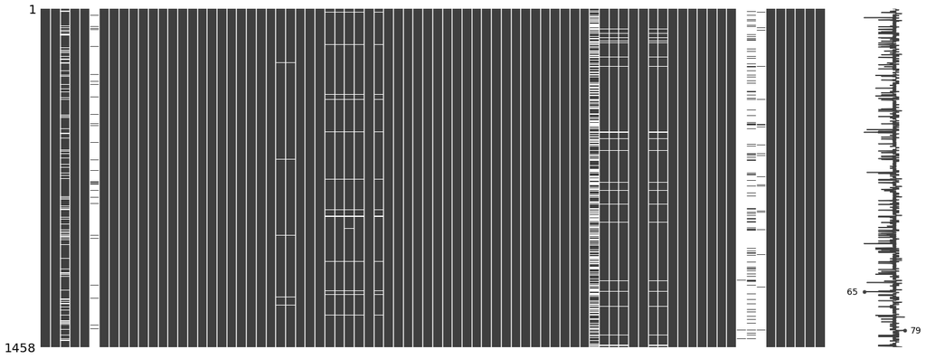

```python
msno.matrix(train_df)
```

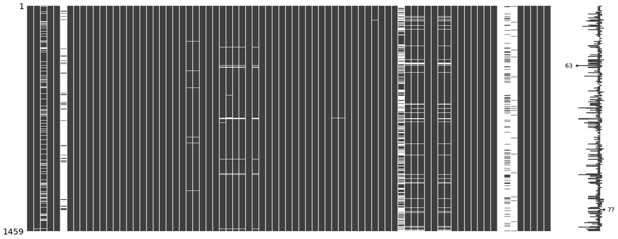

```python
msno.matrix(test_df)
```

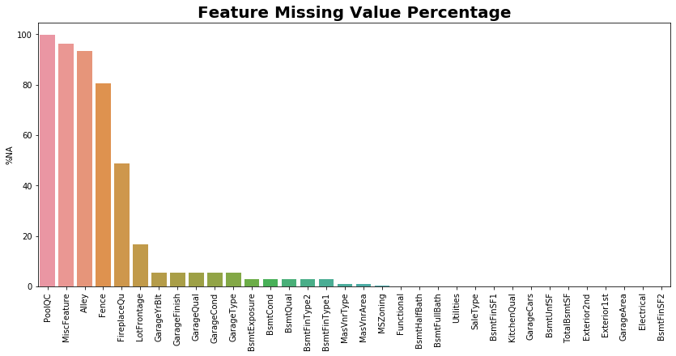

```python
df_na = 100 * df.isnull().sum() / len(df)
df_na = pd.DataFrame(df_na,columns=['%NA'])
df_na = df_na.sort_values('%NA', ascending=False)
df_na = df_na[df_na['%NA']>0]

plt.figure(figsize=(14,6))
sns.barplot(x=df_na.index,y=df_na['%NA'],)
plt.xticks(rotation = '90')
plt.title('Feature Missing Value Percentage',fontsize=20,fontweight='bold')
```

```python
def missing_percentage(df):
    total = df.isnull().sum().sort_values(ascending = False)[df.isnull().sum().sort_values(ascending = False) != 0]
    percent = round(df.isnull().sum().sort_values(ascending = False)/len(df)*100,2)[round(df.isnull().sum().sort_values(ascending = False)/len(df)*100,2) != 0]
    return pd.concat([total, percent], axis=1, keys=['Total Nulls','Percent Null'])

missing_percentage(df)
```

|  | Total Nulls | Percent Null |
| --- | --- | --- |
| PoolQC | 2908 | 99.69 |
| MiscFeature | 2812 | 96.40 |
| Alley | 2719 | 93.21 |
| Fence | 2346 | 80.43 |
| FireplaceQu | 1420 | 48.68 |
| LotFrontage | 486 | 16.66 |
| GarageCond | 159 | 5.45 |
| GarageQual | 159 | 5.45 |
| GarageYrBlt | 159 | 5.45 |
| GarageFinish | 159 | 5.45 |
| GarageType | 157 | 5.38 |
| BsmtCond | 82 | 2.81 |
| BsmtExposure | 82 | 2.81 |
| BsmtQual | 81 | 2.78 |
| BsmtFinType2 | 80 | 2.74 |
| BsmtFinType1 | 79 | 2.71 |
| MasVnrType | 24 | 0.82 |
| MasVnrArea | 23 | 0.79 |
| MSZoning | 4 | 0.14 |
| BsmtHalfBath | 2 | 0.07 |
| Utilities | 2 | 0.07 |
| Functional | 2 | 0.07 |
| BsmtFullBath | 2 | 0.07 |
| BsmtFinSF2 | 1 | 0.03 |
| BsmtFinSF1 | 1 | 0.03 |
| Exterior2nd | 1 | 0.03 |
| BsmtUnfSF | 1 | 0.03 |
| TotalBsmtSF | 1 | 0.03 |
| Exterior1st | 1 | 0.03 |
| SaleType | 1 | 0.03 |
| Electrical | 1 | 0.03 |
| KitchenQual | 1 | 0.03 |
| GarageArea | 1 | 0.03 |
| GarageCars | 1 | 0.03 |

Great! Now let's fill our null values. We'll take a specific approach for each variable, depending on the context:

```python
# 'None' if NA
for i in ['BsmtQual', 'BsmtCond', 'BsmtExposure', 'BsmtFinType1', 'BsmtFinType2',
         'PoolQC', 'MiscFeature', 'Alley', 'Fence', 'GarageType', 'GarageFinish',
         'GarageQual', 'GarageCond', 'MasVnrType', 'FireplaceQu', 'MSSubClass']:
    df[i] = df[i].fillna('None')


# 0 if NA
for i in ['GarageYrBlt', 'GarageArea', 'GarageCars', 'BsmtFinSF1', 'BsmtFinSF2',
          'BsmtUnfSF', 'TotalBsmtSF', 'BsmtFullBath', 'BsmtHalfBath', 'MasVnrArea']:
    df[i] = df[i].fillna(0)


# Exterior1st, Exterior2nd - mode if NA
for i in ['Exterior1st', 'Exterior2nd', 'KitchenQual', 'Electrical', 'MSZoning',
         'SaleType', 'Functional']:
    df[i] = df[i].fillna(df[i].mode()[0])


# LotFrontage - Take median of neighborhood
df['LotFrontage'] = df.groupby('Neighborhood')['LotFrontage'].transform(lambda x: x.fillna(x.median()))


# Utilities - Drop, as all are 'AllPub', except one 'NoSeWa in training data.
df.drop(['Utilities'],inplace=True,axis=1)
```

```python
missing_percentage(df)
```

|  | Total Nulls | Percent Null |
| --- | --- | --- |

Awesome, we've addressed all our null values.

## Additional Preprocessing

### Numerical --> Categorical Variables

Next, let's change datatype on a few numerical variables that would be better represented categorically.

```python
df['MSSubClass'] = df['MSSubClass'].astype(str)
df['OverallCond'] = df['OverallCond'].astype(str)
df['YrSold'] = df['YrSold'].astype(str)
df['MoSold'] = df['MoSold'].astype(str)
```

### Categorical --> Numerical Variables (Label Encoding)

Now, let's go the other way -- let's change datatype on a few categorical variables that would be better represented numerically. Here, we use Label Encoding. Interestingly, Label Encoding outperformed One Hot Encoding on the final test submissions, which is surprising... usually we would expect the opposite to be true.

```python
from sklearn.preprocessing import LabelEncoder

var = ['FireplaceQu', 'BsmtQual', 'BsmtCond', 'GarageQual', 'GarageCond',
        'ExterQual', 'ExterCond','HeatingQC', 'PoolQC', 'KitchenQual',
        'BsmtFinType1', 'BsmtFinType2', 'Functional', 'Fence',
        'BsmtExposure', 'GarageFinish', 'LandSlope', 'LotShape',
        'PavedDrive', 'Street', 'Alley', 'CentralAir', 'MSSubClass',
        'OverallCond', 'YrSold', 'MoSold']

for i in var:
    mdl = LabelEncoder().fit(list(df[i].values))
    df[i] = mdl.transform(list(df[i].values))

df[var].head()
```

|  | FireplaceQu | BsmtQual | BsmtCond | GarageQual | GarageCond | ExterQual | ExterCond | HeatingQC | PoolQC | KitchenQual | ... | LandSlope | LotShape | PavedDrive | Street | Alley | CentralAir | MSSubClass | OverallCond | YrSold | MoSold |
| --- | --- | --- | --- | --- | --- | --- | --- | --- | --- | --- | --- | --- | --- | --- | --- | --- | --- | --- | --- | --- | --- |
| 0 | 3 | 2 | 4 | 5 | 5 | 2 | 4 | 0 | 3 | 2 | ... | 0 | 3 | 2 | 1 | 1 | 1 | 10 | 4 | 2 | 4 |
| 1 | 5 | 2 | 4 | 5 | 5 | 3 | 4 | 0 | 3 | 3 | ... | 0 | 3 | 2 | 1 | 1 | 1 | 5 | 7 | 1 | 7 |
| 2 | 5 | 2 | 4 | 5 | 5 | 2 | 4 | 0 | 3 | 2 | ... | 0 | 0 | 2 | 1 | 1 | 1 | 10 | 4 | 2 | 11 |
| 3 | 2 | 4 | 1 | 5 | 5 | 3 | 4 | 2 | 3 | 2 | ... | 0 | 0 | 2 | 1 | 1 | 1 | 11 | 4 | 0 | 4 |
| 4 | 5 | 2 | 4 | 5 | 5 | 2 | 4 | 0 | 3 | 2 | ... | 0 | 0 | 2 | 1 | 1 | 1 | 10 | 4 | 2 | 3 |

5 rows × 26 columns

### Engineering New Features

Below are a variety of different features introduced to try to improve prediction accuracy in our final models. Interestingly, only 'Total_SF_Main' improved our final test score (which is why the others are commented out).

```python
df['Total_SF_Main'] = df['TotalBsmtSF'] + df['1stFlrSF'] + df['2ndFlrSF']
#df['Total_Porch_SF'] = df['WoodDeckSF'] + df['OpenPorchSF'] + df['EnclosedPorch'] + df['3SsnPorch'] + df['ScreenPorch']
#df['Total_Bathrooms'] = df['BsmtFullBath'] + df['FullBath'] + 0.5*(df['HalfBath'] + df['BsmtHalfBath'])
#df['YrBltRemod'] = df['YearBuilt'] + df['YearRemodAdd']
#df['Total_sqr_footage'] = df['BsmtFinSF1'] + df['BsmtFinSF2'] + df['1stFlrSF'] + df['2ndFlrSF']
#df['haspool'] = df['PoolArea'].apply(lambda x: 1 if x > 0 else 0)
#df['has2ndfloor'] = df['2ndFlrSF'].apply(lambda x: 1 if x > 0 else 0)
#df['hasgarage'] = df['GarageArea'].apply(lambda x: 1 if x > 0 else 0)
#df['hasbsmt'] = df['TotalBsmtSF'].apply(lambda x: 1 if x > 0 else 0)
#df['hasfireplace'] = df['Fireplaces'].apply(lambda x: 1 if x > 0 else 0)
```

## Adjusting Skewed Variables

Alright, now let's address skew in our variables. The more skewed our numeric variables (especially our target variable), the worse our linear regression models will perform. Let's see if we can identify these highly skewed variables and attempt to normalize them through log & boxcox transformations. Let's start with our target variable, SalePrice.

### Target Variable

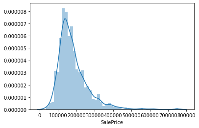

```python
sns.distplot(train_df['SalePrice'])
```

Looks like SalePrice is positively skewed. Let's quantify this further...

```python
mu = train_df['SalePrice'].mean()
med = train_df['SalePrice'].median()
std = train_df['SalePrice'].std()
skew = train_df['SalePrice'].skew()
kurt = train_df['SalePrice'].kurt()

print('SalePrice \n mean = {:.2f} \n median = {:.2f} \n standard deviation = {:.2f} \n skew = {:.2f} \n kurtosis = {:.2f}'.format(mu, med, std, skew, kurt))
```

```
SalePrice
 mean = 180932.92
 median = 163000.00
 standard deviation = 79495.06
 skew = 1.88
 kurtosis = 6.52
```

```
((array([-3.3047554 , -3.04752042, -2.90446807, ...,  2.90446807,
          3.04752042,  3.3047554 ]),
  array([ 34900,  35311,  37900, ..., 625000, 745000, 755000])),
 (74213.25959976624, 180932.91906721535, 0.9320154492892367))
```

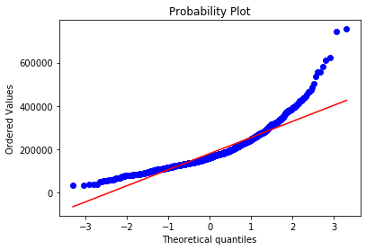

```python
stats.probplot(train_df['SalePrice'], plot=plt)
```

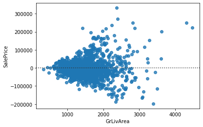

```python
sns.residplot('GrLivArea', 'SalePrice', data=train_df)
```

SalePrice has a positive skew of 1.88 and a positive kurtosis of 6.52 (meaning it's vulnerable to outliers). Further evidence of skew can be seen in the probability plot above. Finally, we see a heteroscedastic relationship between certain independent variables (i.e. GrLivArea) and our target variable. Let's see if we can normalize SalePrice a bit.

```
SalePrice
 mean = 12.02
 median = 12.00
 standard deviation = 0.40
 skew = 0.12
 kurtosis = 0.80
```

```
((array([-3.3047554 , -3.04752042, -2.90446807, ...,  2.90446807,
          3.04752042,  3.3047554 ]),
  array([10.46027076, 10.47197813, 10.54273278, ..., 13.34550853,
         13.52114084, 13.53447435])),
 (0.3985294832980731, 12.024015155682548, 0.9953918721417083))
```

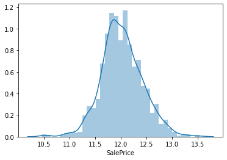

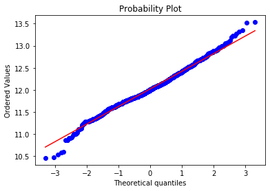

```python
train_df['SalePrice'] = np.log1p(train_df['SalePrice'])

mu = train_df['SalePrice'].mean()
med = train_df['SalePrice'].median()
std = train_df['SalePrice'].std()
skew = train_df['SalePrice'].skew()
kurt = train_df['SalePrice'].kurt()

print('SalePrice \n mean = {:.2f} \n median = {:.2f} \n standard deviation = {:.2f} \n skew = {:.2f} \n kurtosis = {:.2f}'.format(mu, med, std, skew, kurt))

sns.distplot(train_df['SalePrice'])
plt.figure()
stats.probplot(train_df['SalePrice'], plot=plt)
```

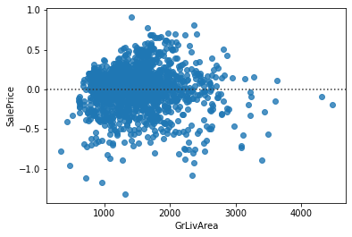

```python
sns.residplot('GrLivArea', 'SalePrice', data=train_df)
```

Great! SalePrice is now much less skewed, more homoscedastic, and more normally distributed. Let's adjust our other highly skewed variables as well, but in a more automated way.

### Independent Variables

```python
numeric_var_skews = pd.DataFrame(df.dtypes[df.dtypes != 'object'].index,columns=['Numeric_Variables'])
numeric_var_skews['Skew'] = numeric_var_skews['Numeric_Variables'].apply(lambda x: df[x].skew())
numeric_var_skews.sort_values('Skew',ascending=False,inplace=True)
numeric_var_skews.reset_index(inplace=True,drop=True)
display(numeric_var_skews)
```

|  | Numeric_Variables | Skew |
| --- | --- | --- |
| 0 | MiscVal | 21.950962 |
| 1 | PoolArea | 17.697766 |
| 2 | LotArea | 13.116240 |
| 3 | LowQualFinSF | 12.090757 |
| 4 | 3SsnPorch | 11.377932 |
| 5 | LandSlope | 4.975813 |
| 6 | KitchenAbvGr | 4.302763 |
| 7 | BsmtFinSF2 | 4.146636 |
| 8 | EnclosedPorch | 4.004404 |
| 9 | ScreenPorch | 3.947131 |
| 10 | BsmtHalfBath | 3.932018 |
| 11 | MasVnrArea | 2.623068 |
| 12 | OpenPorchSF | 2.530660 |
| 13 | WoodDeckSF | 1.845741 |
| 14 | 1stFlrSF | 1.257933 |
| 15 | LotFrontage | 1.103606 |
| 16 | GrLivArea | 1.069300 |
| 17 | Total_SF_Main | 1.009676 |
| 18 | BsmtFinSF1 | 0.981149 |
| 19 | BsmtUnfSF | 0.920161 |
| 20 | 2ndFlrSF | 0.861999 |
| 21 | TotRmsAbvGrd | 0.749618 |
| 22 | Fireplaces | 0.725651 |
| 23 | HalfBath | 0.697024 |
| 24 | TotalBsmtSF | 0.672097 |
| 25 | BsmtFullBath | 0.622735 |
| 26 | OverallCond | 0.569607 |
| 27 | HeatingQC | 0.485784 |
| 28 | FireplaceQu | 0.332782 |
| 29 | BedroomAbvGr | 0.326736 |
| 30 | GarageArea | 0.216968 |
| 31 | OverallQual | 0.189688 |
| 32 | FullBath | 0.165599 |
| 33 | MSSubClass | 0.139781 |
| 34 | YrSold | 0.132064 |
| 35 | BsmtFinType1 | 0.083684 |
| 36 | GarageCars | -0.219410 |
| 37 | YearRemodAdd | -0.450365 |
| 38 | BsmtQual | -0.488614 |
| 39 | YearBuilt | -0.599503 |
| 40 | GarageFinish | -0.610267 |
| 41 | LotShape | -0.618882 |
| 42 | MoSold | -0.646506 |
| 43 | Alley | -0.652041 |
| 44 | BsmtExposure | -1.117896 |
| 45 | KitchenQual | -1.450560 |
| 46 | ExterQual | -1.800989 |
| 47 | Fence | -1.993675 |
| 48 | ExterCond | -2.497774 |
| 49 | BsmtCond | -2.862744 |
| 50 | PavedDrive | -2.979273 |
| 51 | BsmtFinType2 | -3.044545 |
| 52 | GarageQual | -3.074369 |
| 53 | CentralAir | -3.459334 |
| 54 | GarageCond | -3.596139 |
| 55 | GarageYrBlt | -3.906642 |
| 56 | Functional | -4.056212 |
| 57 | Street | -15.502729 |
| 58 | PoolQC | -21.228518 |

```python
high_skew = numeric_var_skews[abs(numeric_var_skews['Skew']) > 0.75]

from scipy.special import boxcox1p
from scipy.stats import boxcox_normmax

high_skew_vars = high_skew['Numeric_Variables']
for var in high_skew_vars:
    df[var] = boxcox1p(df[var], 0.15, #boxcox_normmax(df[var] + 1)
                      )
```

## Dummy Variables

Great! Now that we've tackled skewness, we're ready to create dummy variables.

```python
# Interestingly, not removing the first dummy variable actually improved
# the final test score, thus we keep drop_first=False. Normally, one
# would want to remove one of the dummy variables to avoid collinearity
# in situations where the dummies represent all possible scenarios.
df_dummy = pd.get_dummies(df, #drop_first = True
                         )
df_dummy.shape
```

```
(2917, 220)
```

## Overfitted Variables & Other Outliers

In general, it's a good idea to consider removing variables where the vast majority of values are the same, as this can cause overfitting.

```python
def overfit_reducer(df):
    """
    This function takes in a dataframe and returns a list of features that are overfitted.
    """
    overfit = []
    for i in df.columns:
        counts = df[i].value_counts()
        zeros = counts.iloc[0]
        if zeros / len(df) * 100 > 99.94:
            overfit.append(i)
    overfit = list(overfit)
    return overfit

overfitted_features = overfit_reducer(df_dummy[:train_df.shape[0]])

df_dummy = df_dummy.drop(overfitted_features, axis=1)
```

Let's also remove any additional outliers we may have missed.

```python
# Remove additional outliers
train = df_dummy[:train_df.shape[0]]
Y_train = train_df['SalePrice'].values

import statsmodels.api as sm
ols = sm.OLS(endog = Y_train,
             exog = train)
fit = ols.fit()
test2 = fit.outlier_test()['bonf(p)']

outliers = list(test2[test2<1e-2].index)

print('There were {:.0f} outliers at indices:'.format(len(outliers)))
print(outliers)

train_df = train_df.drop(train_df.index[outliers])
df_dummy = df_dummy.drop(df_dummy.index[outliers])
df_dummy.shape
```

```
There were 9 outliers at indices:
[30, 88, 462, 587, 631, 967, 969, 1322, 1451]
```

```
(2908, 220)
```

## Baseline Model Performance

Awesome! We're finally done cleaning up our data, and we're ready to start making predictions! First we'll define a cross-validation strategy, and then we'll proceed with testing a variety of different base models to see which perform best.

```python
# Helpful imports
from sklearn.model_selection import KFold, cross_val_score, train_test_split
from sklearn.pipeline import make_pipeline
from sklearn.preprocessing import RobustScaler, StandardScaler, MinMaxScaler
from sklearn import metrics
from sklearn.linear_model import Ridge, Lasso, ElasticNet, BayesianRidge, LassoLarsIC, LinearRegression
from sklearn.ensemble import RandomForestRegressor, GradientBoostingRegressor
from sklearn.kernel_ridge import KernelRidge
from sklearn.neighbors import KNeighborsRegressor
from sklearn.tree import DecisionTreeRegressor
import xgboost as xgb
import lightgbm as lgb
from sklearn.svm import SVR

# Designate preprocessed train and test data
train = df_dummy[:train_df.shape[0]]
test = df_dummy[train_df.shape[0]:]
Y_train = train_df['SalePrice'].values

# Cross validation strategy
def rmsle_cv(model):
    kf = KFold(5, shuffle=True, random_state=42).get_n_splits(train.values)
    rmse = np.sqrt(-cross_val_score(model, train.values, Y_train,
            scoring='neg_mean_squared_error', cv=kf))
    return(rmse)
```

```python
models = pd.DataFrame([],columns=['model_name','model_object','score_mean','score_std'])
```

### KNN Regression

```python
knr = KNeighborsRegressor(9, weights='distance')
score = rmsle_cv(knr)
print('KNN Regression score = {:.4f}  (std = {:.4f})'.format(score.mean(), score.std()))
models.loc[len(models)] = ['knr',knr,score.mean(),score.std()]
```

```
KNN Regression score = 0.2253  (std = 0.0048)
```

### SGD Regression

```python
from sklearn.linear_model import SGDRegressor
sgd = make_pipeline(RobustScaler(), SGDRegressor(alpha=1000000000000000,l1_ratio=1))
score = rmsle_cv(sgd)
print('SGD score = {:.4f}  (std = {:.4f})'.format(score.mean(), score.std()))
models.loc[len(models)] = ['sgd',sgd,score.mean(),score.std()]
```

```
SGD score = 0.4089  (std = 0.0371)
```

### Random Forest Regression

```python
rfr = RandomForestRegressor()
score = rmsle_cv(rfr)
print('Random Forest score = {:.4f}  (std = {:.4f})'.format(score.mean(), score.std()))
models.loc[len(models)] = ['rfr',rfr,score.mean(),score.std()]
```

[output not shown]

### Linear Regression

```python
lnr = LinearRegression()
score = rmsle_cv(lnr)
print('Linear Regression score = {:.4f}  (std = {:.4f})'.format(score.mean(), score.std()))
models.loc[len(models)] = ['lnr',lnr,score.mean(),score.std()]
```

```
Linear Regression score = 0.1064  (std = 0.0083)
```

### Ridge

```python
ridg = make_pipeline(RobustScaler(), Ridge(alpha = .17,normalize=True, random_state=4))
score = rmsle_cv(ridg)
print('Ridge score = {:.4f}  (std = {:.4f})'.format(score.mean(), score.std()))
models.loc[len(models)] = ['ridg',ridg,score.mean(),score.std()]
```

```
Ridge score = 0.1034  (std = 0.0067)
```

### Support Vector Regressor

```python
svr = make_pipeline(RobustScaler(), SVR(C= 20, epsilon= 0.02, gamma=0.00046))
score = rmsle_cv(svr)
print('SVR score = {:.4f}  (std = {:.4f})'.format(score.mean(), score.std()))
models.loc[len(models)] = ['svr',svr,score.mean(),score.std()]
```

```
SVR score = 0.0991  (std = 0.0079)
```

### Lasso Regression

```python
lasso = make_pipeline(RobustScaler(), Lasso(alpha = 0.00042, max_iter=100000, random_state=1))
score = rmsle_cv(lasso)
print('Lasso Score = {:.4f}  (std = {:.4f})'.format(score.mean(), score.std()))
models.loc[len(models)] = ['lasso',lasso,score.mean(),score.std()]
```

```
Lasso Score = 0.0991  (std = 0.0061)
```

### Elastic Net Regression

```python
e_net = make_pipeline(RobustScaler(), ElasticNet(alpha = 0.00045, l1_ratio=0.9, random_state=1))
score = rmsle_cv(e_net)
print('Elastic Net score = {:.4f}  (std = {:.4f})'.format(score.mean(), score.std()))
models.loc[len(models)] = ['e_net',e_net,score.mean(),score.std()]
```

```
Elastic Net score = 0.0990  (std = 0.0061)
```

### Kernel Ridge Regression

```python
kr = make_pipeline(RobustScaler(), KernelRidge(alpha=0.04, kernel='polynomial', degree=1, coef0=2.5))
score = rmsle_cv(kr)
print('Kernel Ridge score = {:.4f}  (std = {:.4f})'.format(score.mean(), score.std()))
models.loc[len(models)] = ['kr',kr,score.mean(),score.std()]
```

```
Kernel Ridge score = 0.1000  (std = 0.0066)
```

### Decision Tree Regression

```python
dtr = make_pipeline(RobustScaler(), DecisionTreeRegressor(random_state=0, max_depth=20))
score = rmsle_cv(dtr)
print('Decision Tree score = {:.4f}  (std = {:.4f})'.format(score.mean(), score.std()))
models.loc[len(models)] = ['dtr',dtr,score.mean(),score.std()]
```

```
Decision Tree score = 0.1894  (std = 0.0115)
```

### Gradient Boosting Regression

```python
gbr = GradientBoostingRegressor(n_estimators=3000,
            learning_rate=0.05, max_depth=4, max_features='sqrt',
            min_samples_leaf=1, min_samples_split=2, loss='huber',
            random_state=5,)
score = rmsle_cv(gbr)
print('Gradient Boosting score = {:.4f}  (std = {:.4f})'.format(score.mean(), score.std()))
models.loc[len(models)] = ['gbr',gbr,score.mean(),score.std()]
```

```
Gradient Boosting score = 0.1030  (std = 0.0089)
```

### LightGBM Regression

```python
lgbr = lgb.LGBMRegressor(objective='regression',num_leaves=5,
        learning_rate=0.05, n_estimators=720, max_bin = 55,
        bagging_fraction = 0.8, bagging_freq = 5,
        feature_fraction = 0.2319, feature_fraction_seed=9, bagging_seed=9,
        min_data_in_leaf =6, min_sum_hessian_in_leaf = 11)
score = rmsle_cv(lgbr)
print('LightGBM score = {:.4f}  (std = {:.4f})'.format(score.mean(), score.std()))
models.loc[len(models)] = ['lgbr',lgbr,score.mean(),score.std()]
```

```
LightGBM score = 0.1028  (std = 0.0063)
```

### XGBoost Regression

```python
xgbr = xgb.XGBRegressor(colsample_bytree=0.4603, gamma=0.0468,
        learning_rate=0.05, max_depth=3, min_child_weight=1.7817,
        n_estimators=2200, reg_alpha=0.4640, reg_lambda=0.8571,
        subsample=0.5213, silent=True, random_state =7, nthread = -1)
score = rmsle_cv(xgbr)
print('XGBoost score = {:.4f}  (std = {:.4f})'.format(score.mean(), score.std()))
models.loc[len(models)] = ['xgbr',xgbr,score.mean(),score.std()]
```

[output not shown]

### All Models Ranked:

```python
models.sort_values(by='score_mean',inplace=True)
models.reset_index(inplace=True,drop=True)
models
```

|  | model_name | model_object | score_mean | score_std |
| --- | --- | --- | --- | --- |
| 0 | e_net | (RobustScaler(copy=True, quantile_range=(25.0,... | 0.099040 | 0.006107 |
| 1 | lasso | (RobustScaler(copy=True, quantile_range=(25.0,... | 0.099052 | 0.006089 |
| 2 | svr | (RobustScaler(copy=True, quantile_range=(25.0,... | 0.099071 | 0.007941 |
| 3 | kr | (RobustScaler(copy=True, quantile_range=(25.0,... | 0.099997 | 0.006571 |
| 4 | lgbr | LGBMRegressor(bagging_fraction=0.8, bagging_fr... | 0.102830 | 0.006320 |
| 5 | gbr | GradientBoostingRegressor(alpha=0.9, ccp_alpha... | 0.102971 | 0.008909 |
| 6 | ridg | (RobustScaler(copy=True, quantile_range=(25.0,... | 0.103362 | 0.006744 |
| 7 | xgbr | XGBRegressor(base_score=None, booster=None, co... | 0.104543 | 0.006468 |
| 8 | lnr | LinearRegression(copy_X=True, fit_intercept=Tr... | 0.106361 | 0.008303 |
| 9 | rfr | RandomForestRegressor(bootstrap=True, ccp_alph... | 0.129406 | 0.004995 |
| 10 | dtr | (RobustScaler(copy=True, quantile_range=(25.0,... | 0.189363 | 0.011477 |
| 11 | knr | KNeighborsRegressor(algorithm='auto', leaf_siz... | 0.225321 | 0.004786 |
| 12 | sgd | (RobustScaler(copy=True, quantile_range=(25.0,... | 0.408903 | 0.037110 |

Awesome! We have some pretty strong predictive models so far. Let's see if we can improve our predictions through ensembling.

## Ensemble Models: Simple Average

Our goal here is to identify which combinations of models give the best overall cross validation score when taking a simple average of their predictions.

First we'll create the class "AveragingModels" that calculates the simple average prediction of a basket of models.

```python
from sklearn.base import BaseEstimator, TransformerMixin, RegressorMixin, clone

class AveragingModels(BaseEstimator, RegressorMixin, TransformerMixin):
    def __init__(self, models):
        self.models = models

    def fit(self, X, y):
        self.models_ = [clone(x) for x in self.models]
        for model in self.models_:
            model.fit(X, y)
        return self

    def predict(self, X):
        predictions = np.column_stack([
            model.predict(X) for model in self.models_
        ])
        return np.mean(predictions, axis=1)
```

Next, we'll create a list of every combination of the models with score_mean < 0.11.

```python
from itertools import combinations

def subset(lst, count):
    return list(set(combinations(lst, count)))

model_list = list(models[models['score_mean']<0.11]['model_name'])
combo = list()

for i in range(1,len(model_list)):
    combo = combo + subset(model_list, i)

print('There are {:.0f} combinations. First 20 include:'.format(len(combo)))
combo[:20]
```

```
There are 510 combinations. First 20 include:
```

```
[('svr',),
 ('ridg',),
 ('lnr',),
 ('lgbr',),
 ('gbr',),
 ('kr',),
 ('e_net',),
 ('lasso',),
 ('xgbr',),
 ('e_net', 'ridg'),
 ('kr', 'ridg'),
 ('lgbr', 'ridg'),
 ('svr', 'lnr'),
 ('lasso', 'ridg'),
 ('gbr', 'xgbr'),
 ('lgbr', 'gbr'),
 ('svr', 'xgbr'),
 ('lgbr', 'lnr'),
 ('e_net', 'lgbr'),
 ('svr', 'lgbr')]
```

And finally, we'll apply AveragingModels to every combination. Note, this may take a while.

```python
model_scores = pd.DataFrame([],columns=['models_averaged','score_mean','score_std'])

for i in range(len(combo)):
    mods = list()
    for j in range(len(combo[i])):
        mods = mods + list(models[models['model_name']==list(combo[i])[j]]['model_object'])
    avg = AveragingModels(models = mods)
    score = rmsle_cv(avg)
    model_scores.loc[len(model_scores)] = [combo[i],score.mean(),score.std()]

model_scores = model_scores.sort_values(by='score_mean')
```

```python
model_scores.to_csv('simple_average_scores.csv')
```

```python
model_scores.head(25)
```

|  | models_averaged | score_mean | score_std |
| --- | --- | --- | --- |
| 248 | (e_net, svr, gbr) | 0.094975 | 0.007544 |
| 59 | (lasso, svr, gbr) | 0.094979 | 0.007540 |
| 293 | (e_net, lasso, svr, lgbr, gbr) | 0.095026 | 0.006907 |
| 346 | (e_net, lasso, svr, gbr, xgbr) | 0.095083 | 0.006951 |
| 218 | (e_net, lasso, svr, gbr) | 0.095164 | 0.007205 |
| 1 | (e_net, svr, lgbr, gbr) | 0.095167 | 0.007098 |
| 84 | (lasso, svr, lgbr, gbr) | 0.095171 | 0.007096 |
| 426 | (e_net, svr, gbr, xgbr) | 0.095178 | 0.007165 |
| 418 | (lasso, svr, gbr, xgbr) | 0.095186 | 0.007163 |
| 90 | (e_net, svr, gbr, ridg, xgbr) | 0.095273 | 0.007138 |
| 64 | (lasso, svr, gbr, ridg, xgbr) | 0.095274 | 0.007136 |
| 169 | (e_net, lasso, svr, lgbr, gbr, ridg) | 0.095280 | 0.006921 |
| 45 | (e_net, lasso, svr, lgbr, gbr, ridg, xgbr) | 0.095285 | 0.006813 |
| 91 | (e_net, lasso, svr, lgbr, gbr, xgbr) | 0.095287 | 0.006783 |
| 184 | (lasso, svr, lgbr, gbr, ridg) | 0.095292 | 0.007082 |
| 264 | (e_net, svr, lgbr, gbr, ridg) | 0.095294 | 0.007084 |
| 13 | (e_net, lasso, svr, gbr, ridg, xgbr) | 0.095300 | 0.006958 |
| 149 | (lasso, svr, gbr, xgbr, lnr) | 0.095318 | 0.007384 |
| 132 | (e_net, svr, gbr, xgbr, lnr) | 0.095319 | 0.007388 |
| 185 | (e_net, lasso, svr, lgbr, gbr, xgbr, lnr) | 0.095334 | 0.006981 |
| 94 | (lasso, svr, lgbr, gbr, lnr) | 0.095340 | 0.007314 |
| 51 | (e_net, svr, lgbr, gbr, lnr) | 0.095344 | 0.007317 |
| 296 | (e_net, lasso, svr, lgbr, gbr, lnr) | 0.095384 | 0.007140 |
| 323 | (e_net, lasso, svr, gbr, xgbr, lnr) | 0.095401 | 0.007188 |
| 209 | (e_net, svr, lgbr, gbr, xgbr, lnr) | 0.095409 | 0.007118 |

Awesome! Above are the top 25 model combinations by cross validation score.

**Note:** After testing many of the top combinations above on the final Kaggle test data, we saw the best performance overall from (lasso, gbr, lgbr, kr).

```python
simple_avg_final = AveragingModels(models = (lasso, gbr, lgbr, kr))
score = rmsle_cv(simple_avg_final)
print('Simple Average score = {:.4f}  (std = {:.4f})'.format(score.mean(), score.std()))
```

```
Simple Average score = 0.0959  (std = 0.0067)
```

## Stacking Models: Meta-Model

Let's see if we can improve our predictions even further through applying a meta-model atop our base model predictions. Keeping consistent with our cross-validation strategy, we'll use StackingCVRegressor to train our meta-model (as opposed to StackingRegressor, which does not train the meta-model using the out-of-fold cross-validation predictions from the base models).

```python
from mlxtend.regressor import StackingCVRegressor

stacked = StackingCVRegressor(regressors=(lasso, gbr, lgbr, kr),
                                meta_regressor=lasso,
                                use_features_in_secondary=True)

score = rmsle_cv(stacked)
print('Stacked score = {:.8f}  (std = {:.4f})'.format(score.mean(), score.std()))
```

```
Stacked score = 0.09567798  (std = 0.0065)
```

Great! We were able to improve our score using a stacked model approach. In particular, defining our base models to be the same set of models for which we received the best simple-average test results above (lasso, gbr, lgbr, kr), we were able to marginally improve our cross-validation score by applying the lasso meta-model.

## Final Predictions

Yahoo! We made it! For our final prediction, we'll create an ensemble model that is

- 50% a simple average of lasso, kr, gbr, lgbr.
- 50% a stacked meta model with base svr, ridg, and xgbr and meta regressor e_net.

**Interesting sidenote:** While incorporating the stacked meta-model approach into our final prediction ensemble did improve predictive power in a variety of cases, my strongest result overall when submitting to Kaggle (.11997) came from a simple average of Lasso, Gradient Boost, LightGMB, and Kernel Ridge.

```python
stacked_final = StackingCVRegressor(regressors=(svr, ridg, xgbr),
                                meta_regressor=e_net,
                                use_features_in_secondary=True)

score = rmsle_cv(stacked_final)
print('stacked_final score = {:.8f}  (std = {:.4f})'.format(score.mean(), score.std()))
```

[output not shown]

[output cut: 186 more lines]

[output not shown]

```python
model_1 = simple_avg_final
model_2 = stacked_final
mod_1_share = .5
mod_2_share = .5

model_1.fit(train.values, Y_train)
model_1_test_predictions = np.expm1(model_1.predict(test.values))

model_2.fit(train.values, Y_train)
model_2_test_predictions = np.expm1(model_2.predict(test.values))

test_predictions = mod_1_share * model_1_test_predictions + mod_2_share * model_2_test_predictions
```

[output not shown]

```python
test_id = pd.read_csv('test.csv')[['Id']]
test_id['SalePrice'] = np.round(test_predictions,2)
test_id.to_csv('predictions_simple(lasso,gbr,lgbr,kr)_meta(e_net,svr,ridg,xgbr).csv',index=False)
```

Thank you so much for going on this journey with me! I hope you found this notebook helpful. Please let me know if you have any questions or if you have suggestion for improving upon my approach - having a conversation is the best way to improve. 😊